# Income Prediction——Find the Donators

Bangguo Wang

```r
rm(list=ls()) # clear all the existed variables
# call related packages and R scripts
library(ggplot2)
library(rpart)
library(kernlab)
library(randomForest)
source('multiplot.R')
source('validation.R')
source('evaluation.R')
source('find_best_p.R')
```

## Download the data

Since we have been downloaded the data from website and save it on the local folder, so here we just need to reload them from the folder

```r
load('rawData.Rdata')
train = rawData[[1]]
test = rawData[[2]]
```

## Clean data

Firstly, there is a space in every categorical variables (for example:‘Private’,‘Female’), so we need to delete these space.

```r
# the columns of categorical variables
cat_cols = c(2,4,6,7,8,9,10,14,15)
# delete all the space
temp = apply(train[,cat_cols],2,function(x) as.factor(gsub(' ','',x)))
train[, cat_cols] = data.frame(temp)

# the same procedure for the test data
temp = apply(test[,cat_cols],2,function(x) as.factor(gsub(' ','',x)))
test[, cat_cols] = data.frame(temp)
```

### clean the train data

Before we clean the data , we need to know what the data looks like and have a general understanding of the data

```r
# the number of observations and variables
dim(train)
```

```
## [1] 32561    15
```

```r
# let's see some examples of the train data
head(train)
```

```
##   age        workclass fnlwgt education education.num     marital.status
## 1  39        State-gov  77516 Bachelors            13      Never-married
## 2  50 Self-emp-not-inc  83311 Bachelors            13 Married-civ-spouse
## 3  38          Private 215646   HS-grad             9           Divorced
## 4  53          Private 234721      11th             7 Married-civ-spouse
## 5  28          Private 338409 Bachelors            13 Married-civ-spouse
## 6  37          Private 284582   Masters            14 Married-civ-spouse
##          occupation  relationship  race    sex capital.gain capital.loss
## 1      Adm-clerical Not-in-family White   Male         2174            0
## 2   Exec-managerial       Husband White   Male            0            0
## 3 Handlers-cleaners Not-in-family White   Male            0            0
## 4 Handlers-cleaners       Husband Black   Male            0            0
## 5    Prof-specialty          Wife Black Female            0            0
## 6   Exec-managerial          Wife White Female            0            0
##   hours.per.week native.country     y
## 1             40  United-States <=50K
## 2             13  United-States <=50K
## 3             40  United-States <=50K
## 4             40  United-States <=50K
## 5             40           Cuba <=50K
## 6             40  United-States <=50K
```

```r
# summary the data
summary(train)
```

```
##       age                   workclass         fnlwgt
##  Min.   :17.00   Private         :22696   Min.   :  12285
##  1st Qu.:28.00   Self-emp-not-inc: 2541   1st Qu.: 117827
##  Median :37.00   Local-gov       : 2093   Median : 178356
##  Mean   :38.58   ?               : 1836   Mean   : 189778
##  3rd Qu.:48.00   State-gov       : 1298   3rd Qu.: 237051
##  Max.   :90.00   Self-emp-inc    : 1116   Max.   :1484705
##                  (Other)         :  981
##         education     education.num                 marital.status
##  HS-grad     :10501   Min.   : 1.00   Divorced             : 4443
##  Some-college: 7291   1st Qu.: 9.00   Married-AF-spouse    :   23
##  Bachelors   : 5355   Median :10.00   Married-civ-spouse   :14976
##  Masters     : 1723   Mean   :10.08   Married-spouse-absent:  418
##  Assoc-voc   : 1382   3rd Qu.:12.00   Never-married        :10683
##  11th        : 1175   Max.   :16.00   Separated            : 1025
##  (Other)     : 5134                   Widowed              :  993
##            occupation           relationship                   race
##  Prof-specialty :4140   Husband       :13193   Amer-Indian-Eskimo:  311
##  Craft-repair   :4099   Not-in-family : 8305   Asian-Pac-Islander: 1039
##  Exec-managerial:4066   Other-relative:  981   Black             : 3124
##  Adm-clerical   :3770   Own-child     : 5068   Other             :  271
##  Sales          :3650   Unmarried     : 3446   White             :27816
##  Other-service  :3295   Wife          : 1568
##  (Other)        :9541
##      sex         capital.gain    capital.loss    hours.per.week
##  Female:10771   Min.   :    0   Min.   :   0.0   Min.   : 1.00
##  Male  :21790   1st Qu.:    0   1st Qu.:   0.0   1st Qu.:40.00
##                 Median :    0   Median :   0.0   Median :40.00
##                 Mean   : 1078   Mean   :  87.3   Mean   :40.44
##                 3rd Qu.:    0   3rd Qu.:   0.0   3rd Qu.:45.00
##                 Max.   :99999   Max.   :4356.0   Max.   :99.00
##
##        native.country      y
##  United-States:29170   <=50K:24720
##  Mexico       :  643   >50K : 7841
##  ?            :  583
##  Philippines  :  198
##  Germany      :  137
##  Canada       :  121
##  (Other)      : 1709
```

We can see that there are 32561 observations, 15 variables. Among the 15 variables, the last variable **y** is response variable, whether the person’s income is *>50K* or *<=50K*.  
Among the 14 predictors, there are 6 numerical variables: **age**, **education.num**, **capital.gain**, **capital.loss**, **hours.per.week** and 8 categorical variables.

##### (1) Deleting the duplicated data

There are 24 duplicated observations in the train data, so we need to delete them.

```r
# the number of obs before deleting duplicated obs
num_obs= dim(train)[1]
# the number of duplicated obs
num_duplicated = sum(duplicated(train))
# pick one example to show
duplicated_example1_age = train$age[duplicated(train)][1]
duplicated_example1_fnlwgt=train$fnlwgt[duplicated(train)][1]

# example of duplicated observations
print(train[train$age==duplicated_example1_age & train$fnlwgt==duplicated_example1_fnlwgt,])
```

```
##      age workclass fnlwgt education education.num marital.status
## 4326  25   Private 308144 Bachelors            13  Never-married
## 4882  25   Private 308144 Bachelors            13  Never-married
##        occupation  relationship  race  sex capital.gain capital.loss
## 4326 Craft-repair Not-in-family White Male            0            0
## 4882 Craft-repair Not-in-family White Male            0            0
##      hours.per.week native.country     y
## 4326             40         Mexico <=50K
## 4882             40         Mexico <=50K
```

```r
# use unique function to get the unique obs
train = unique(train)
# check
cat('Number of obs for original train data:',num_obs,
    '\nNumber of duplicated obs:',num_duplicated,
    '\nNumber of obs after deleting the duplicated obs:',dim(train)[1])
```

```
## Number of obs for original train data: 32561
## Number of duplicated obs: 24
## Number of obs after deleting the duplicated obs: 32537
```

##### (2) Check specifically at each numerical variables

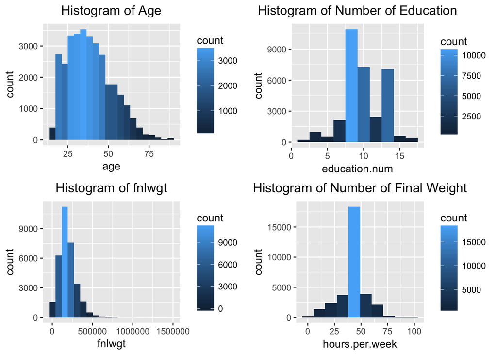

```r
# age variable
g1=ggplot(train, aes(age)) +
  geom_histogram(bins = 20, aes(fill =..count..))+labs(title='Histogram of Age')+
  theme(plot.title=element_text(hjust=0.5))
# fnlwgt variable
g2=ggplot(train, aes(fnlwgt)) + geom_histogram(bins = 20, aes(fill =..count..))+
  labs(title='Histogram of fnlwgt')+theme(plot.title=element_text(hjust=0.5))
# education.num variable
g3=ggplot(train, aes(education.num)) + geom_histogram(bins = 10, aes(fill =..count..))+
  labs(title='Histogram of Number of Education')+theme(plot.title=element_text(hjust=0.5))
# hours.per.week variable
g4=ggplot(train, aes(hours.per.week)) + geom_histogram(bins = 10, aes(fill =..count..))+
  labs(title='Histogram of Number of Final Weight')+theme(plot.title=element_text(hjust=0.5))
multiplot(g1, g2, g3, g4,cols=2)
```

1. From the summary and plot, we can know that, the mean of **age** is 38.58, median is 37.This variable has a long tail to right.The range is (17,90), but most values fall in (25,50) interval.
2. The mean of **education.num** is 10.08, median is 10, range from (1,16), most people have (7,14) years education
3. The **fnlwgt** variable have a large range, (12285,1484705), most of them fall in (150000,200000). Using the quantile method to detect the outliers, we can find that there are 152 (0.47%) extremely large values. To avoid bias caused by these observations,we should delete them

```r
Q1=quantile(train$fnlwgt,0.25)
Q3=quantile(train$fnlwgt,0.75)
# here we use, 3*(Q3-Q1),insteads of 1.5*(Q3-Q1), because the number of obs whose fnlwgt is larger than (Q3 + 1.5*(Q3-Q1)) is too much.
up = Q3 + 3*(Q3-Q1) # up=594723
down = Q1 - 3*(Q3-Q1) #down<0
# extremely large values:
train$fnlwgt[train$fnlwgt>up]
```

```
##   [1]  633742  635913  860348 1033222  680390  767403  795830  910398
##   [9]  672412  675421  758700  656036  716416  637222  664821  598606
##  [17]  617021  596776  640383  611029  746786  656036  688355  628797
##  [25]  632613 1184622  913447  632593  595000  703067  749105  642830
##  [33]  704108  595000  604506  716066  659273  972354  608184 1226583
##  [41]  664670  791084  917220  637080  671292  648223  745768  647882
##  [49] 1038553  732569  721161  607848  632834  849857  691903  684015
##  [57]  695136  698418  734193  737315  691830  607799  660870  680390
##  [65]  857532 1484705  755858  654141  930948  664366  606111  634226
##  [73] 1268339  698363  617860  615893 1366120  651396  631947  806552
##  [81]  604537 1455435  659504  750972  607848  889965  659558  609935
##  [89]  608184  615367  660461  617898  953588  609789  598995  609789
##  [97]  663394  732102  709445  609789  636017  703107  595088  607848
## [105]  602513  694812  598802  806316 1033222  599629  738812  618191
## [113]  668319  682947  816750  597843  595461  704108  745817 1161363
## [121]  673764  809585  653574  706026  721712  615367 1097453 1085515
## [129]  695411  761006  604045  605502  709798 1125613  604380  609789
## [137]  706180  606752  673764  799281  657397  653574  745768  857532
## [145]  715938  747719  766115  749636  668362  981628  746432  693066
```

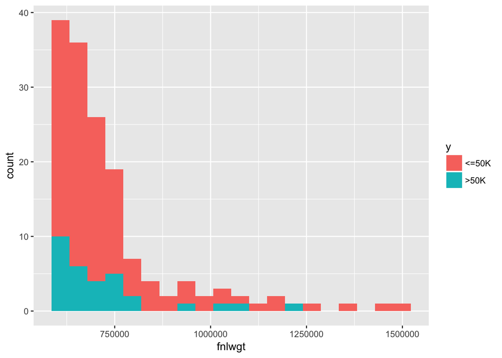

```r
# let's see the y distribution of these extremely observations.
# There are some points mixed together,especially in the (594723,1250000) interval.
ggplot(train[train$fnlwgt>up,], aes(fnlwgt)) + geom_histogram(bins = 20, aes(fill =y))
```

```r
# delete the extremely observations
train = train[train$fnlwgt<=up,]
```

4. The working **hours.per.week** fall in the range of (1,99). About 64% of people work for 30~50 hours per week. So its distribution has a high peak. The Other observations are nearly symmetry distributed, falling in (1,30) and (50,90) interval. When using the quantile mehod to determine the outliers, we could find that there will be 3614 (11.1%) observations, it’s too much, so here we don’t use it. Another thing that should be pay attention to is, there are lots of observations whose per.hours.week is exactly 99, it’s more likely that those people who work for more than 99 hours also be recorded as 99 hours. But Watching the plot below, we can see that the proportion of `>50K` and `<=50K` is almost the same in the train data and in the test data, among those working 99 hours per week. So considering that it might provide us with some useful information for prediction, here we retain the original data.

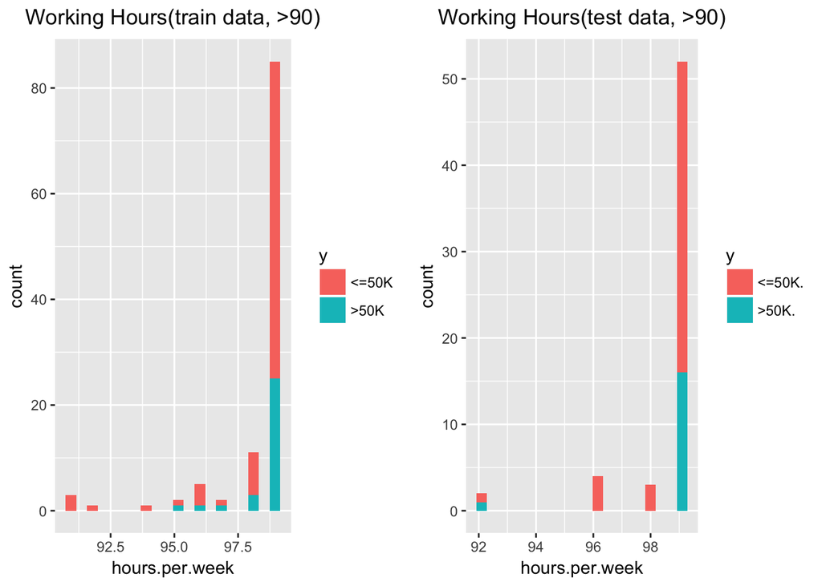

```r
g1 = ggplot(train[train$hours.per.week>90,], aes(hours.per.week)) + geom_histogram(bins = 20, aes(fill =y))+
  labs(title='Working Hours(train data, >90)')+theme(plot.title=element_text(hjust=0.5))

g2 = ggplot(test[test$hours.per.week>90,], aes(hours.per.week)) + geom_histogram(bins = 20, aes(fill =y))+
  labs(title='Working Hours(test data, >90)')+theme(plot.title=element_text(hjust=0.5))
multiplot(g1, g2,cols=2)
```

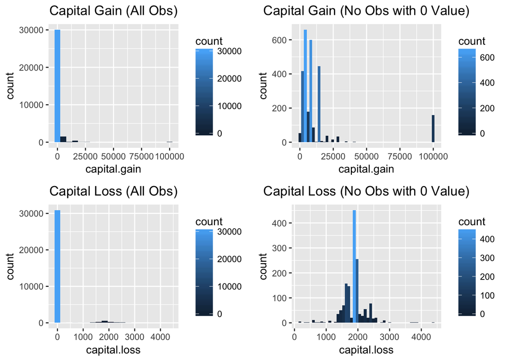

```r
# capital.gain variable
g5=ggplot(train, aes(capital.gain)) + geom_histogram(bins = 20, aes(fill =..count..))+
  labs(title='Capital Gain (All Obs)')+theme(plot.title=element_text(hjust=0.5))
# capital.loss variable
g6=ggplot(train, aes(capital.loss)) + geom_histogram(bins = 20, aes(fill =..count..))+
  labs(title='Capital Loss (All Obs)')+theme(plot.title=element_text(hjust=0.5))
# look specifically the distribution of capital.gain without 0 value
g7=ggplot(train[train$capital.gain!=0,], aes(capital.gain)) + geom_histogram(bins = 50, aes(fill =..count..))+
  labs(title='Capital Gain (No Obs with 0 Value)')+theme(plot.title=element_text(hjust=0.5))
# look specifically the distribution of capital.gain without 0 value
g8=ggplot(train[train$capital.loss!=0,], aes(capital.loss)) + geom_histogram(bins = 50, aes(fill =..count..))+
  labs(title='Capital Loss (No Obs with 0 Value)')+theme(plot.title=element_text(hjust=0.5))
multiplot(g5, g6, g7, g8,cols=2)
```

5. From the summary and plot, we know that **capital.gain** and **capital.loss** are severely unnormal,severely skewed. Most of the observations have 0 capital.gain ( 91.66% ) and capital loss ( 95.33% ). But there are also some extremely large values, so the range is very large for these two variables. For such data, we can make a log tansformation for them. But because there are 0 value, so we can add 1 to all of them before we make a log transformation. What’s more, there is one thing that should be emphasized, that is, there are 159 observations that have exactly 99999 capital gain, while there are no observations who have capital gain is in the large interval (45000,99998). So here we consider these observations as outliers. (here we don’t use quantile method because there are too many points detected to be outliers). With the same idea, we delete observations who has more than 4000 capital loss.

```r
# delete the outliers
train = train[train$capital.gain!=99999,]
train = train[train$capital.loss<4000,]

# make a log transformation
train$capital.gain = log(train$capital.gain+1)
train$capital.loss = log(train$capital.loss+1)
```

##### (3) Check specifically at each categorical variables

Usually, we need to apply one-hot encoding for categorical variables. But since R pakages can recognize them, so here we don’t need to do it.

There are some varialbes, **education**, **occupation**, **native.country**, that use `(other)` to replace their other levels, we can dive into these variables to see their details

```r
summary(train$education)
```

```
##         10th         11th         12th      1st-4th      5th-6th
##          923         1168          428          163          331
##      7th-8th          9th   Assoc-acdm    Assoc-voc    Bachelors
##          643          509         1064         1378         5281
##    Doctorate      HS-grad      Masters    Preschool  Prof-school
##          400        10423         1696           50          529
## Some-college
##         7237
```

```r
summary(train$occupation)
```

```
##                 ?      Adm-clerical      Armed-Forces      Craft-repair
##              1827              3747                 9              4066
##   Exec-managerial   Farming-fishing Handlers-cleaners Machine-op-inspct
##              4008               987              1355              1988
##     Other-service   Priv-house-serv    Prof-specialty   Protective-serv
##              3273               147              4056               645
##             Sales      Tech-support  Transport-moving
##              3608               920              1587
```

```r
summary(train$native.country)
```

```
##                          ?                   Cambodia
##                        572                         19
##                     Canada                      China
##                        120                         75
##                   Columbia                       Cuba
##                         57                         95
##         Dominican-Republic                    Ecuador
##                         69                         28
##                El-Salvador                    England
##                        101                         90
##                     France                    Germany
##                         29                        136
##                     Greece                  Guatemala
##                         29                         61
##                      Haiti         Holand-Netherlands
##                         44                          1
##                   Honduras                       Hong
##                         13                         20
##                    Hungary                      India
##                         13                         97
##                       Iran                    Ireland
##                         43                         24
##                      Italy                    Jamaica
##                         73                         81
##                      Japan                       Laos
##                         61                         18
##                     Mexico                  Nicaragua
##                        630                         32
## Outlying-US(Guam-USVI-etc)                       Peru
##                         14                         31
##                Philippines                     Poland
##                        197                         60
##                   Portugal                Puerto-Rico
##                         37                        114
##                   Scotland                      South
##                         12                         79
##                     Taiwan                   Thailand
##                         50                         18
##            Trinadad&Tobago              United-States
##                         18                      28879
##                    Vietnam                 Yugoslavia
##                         67                         16
```

```r
# delete the observations with unknown values
unknown_obs = train$workclass=='?' | train$native.country=='?' | train$occupation=='?'
train = train[!unknown_obs,]
```

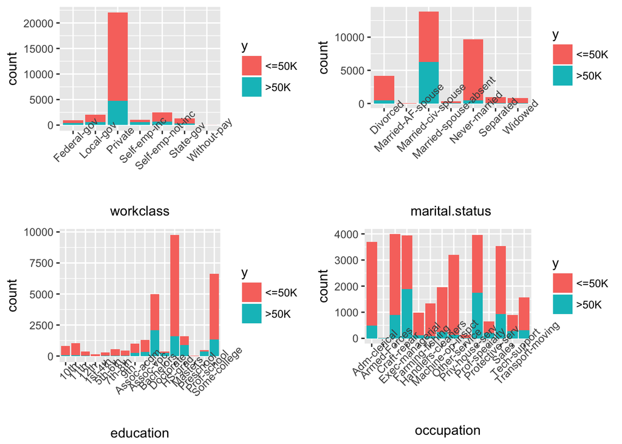

```r
# workclass variable
g1=ggplot(train)+geom_bar(aes(x=workclass,fill=y))+theme(axis.text.x=element_text(angle=45))
# education variable
g2=ggplot(train)+geom_bar(aes(x=education,fill=y))+theme(axis.text.x=element_text(angle=45))
# marital.status variable
g3=ggplot(train)+geom_bar(aes(x=marital.status,fill=y))+theme(axis.text.x=element_text(angle=45))
# occupation variable
g4=ggplot(train)+geom_bar(aes(x=occupation,fill=y))+theme(axis.text.x=element_text(angle=45))
multiplot(g1, g2, g3, g4,cols=2)
```

7. For **workclass** varialbe, most people (73.8%) are ‘Private’, there are just 14 people who are ‘Without-pay’, though the sample of this level is small, here we don’t need to change it, because among these 14 people, all of them are `<=50K`, so it might be a good predictor.

```r
train$workclass = as.factor(as.character(train$workclass))
```

```r
# the y label of people who are Married-AF-spouse
# it's not a good preditor and because its sample size is very small, we should change it
c(train$y[train$marital.status=='Married-AF-spouse'],test$y[test$marital.status=='Married-AF-spouse'])
```

```
##  [1] 1 1 1 1 1 2 1 2 1 2 2 2 2 2 1 1 1 2 1 2 2 2 1 1 1 1 2 1 1 2 1 1 1 2 1
```

```r
# change the Married-AF-spouse level into Married-spouse-absent level
train$marital.status = as.character(train$marital.status)
train$marital.status[train$marital.status =='Married-AF-spouse'] = 'Married-spouse-absent'
train$marital.status = as.factor(train$marital.status)
```

```r
# the y label of people who are Armed-Forces
c(train$y[train$occupation=='Armed-Forces'],test$y[test$occupation=='Armed-Forces'])
```

```
##  [1] 1 1 1 1 1 1 1 2 1 1 2 2 2 2 1
```

```r
# change the Armed-Forces level into Other-service level
train$occupation = as.character(train$occupation)
train$occupation[train$occupation=='Armed-Forces'] = 'Other-service'
train$occupation = as.factor(train$occupation)
```

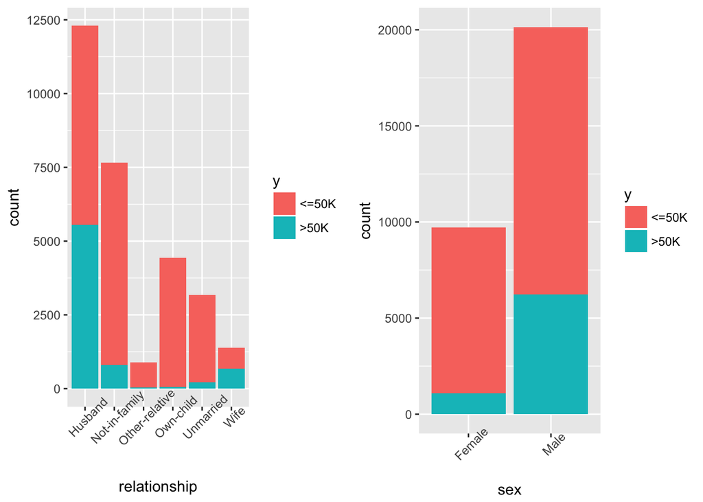

```r
# relationship variable
g5=ggplot(train)+geom_bar(aes(x=relationship,fill=y))+theme(axis.text.x=element_text(angle=45))
# sex variable
g6=ggplot(train)+geom_bar(aes(x=sex,fill=y))+theme(axis.text.x=element_text(angle=45))
multiplot(g5, g6,cols=2)
```

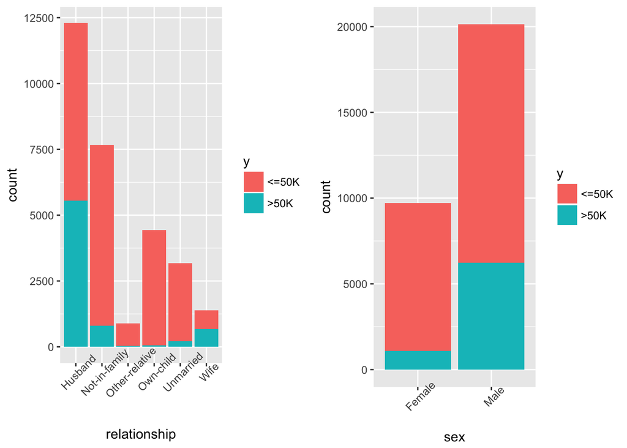

```r
# race variable
g7 = ggplot(train)+geom_bar(aes(x=race,fill=y))+theme(axis.text.x=element_text(angle=45))

# look specifically two smallest level Amer-Indian-Eskimo and Other
logit = train$race=='Amer-Indian-Eskimo' | train$race=='Other'
temp = train[logit,]
g8 = ggplot(temp)+geom_bar(aes(x=race,fill=y))
multiplot(g5, g6,cols=2)
```

```r
# change the smallest level Amer-Indian-Eskimo into Other
train$race = as.character(train$race)
train$race[train$race=='Amer-Indian-Eskimo']='Other'
train$race = as.factor(train$race)
```

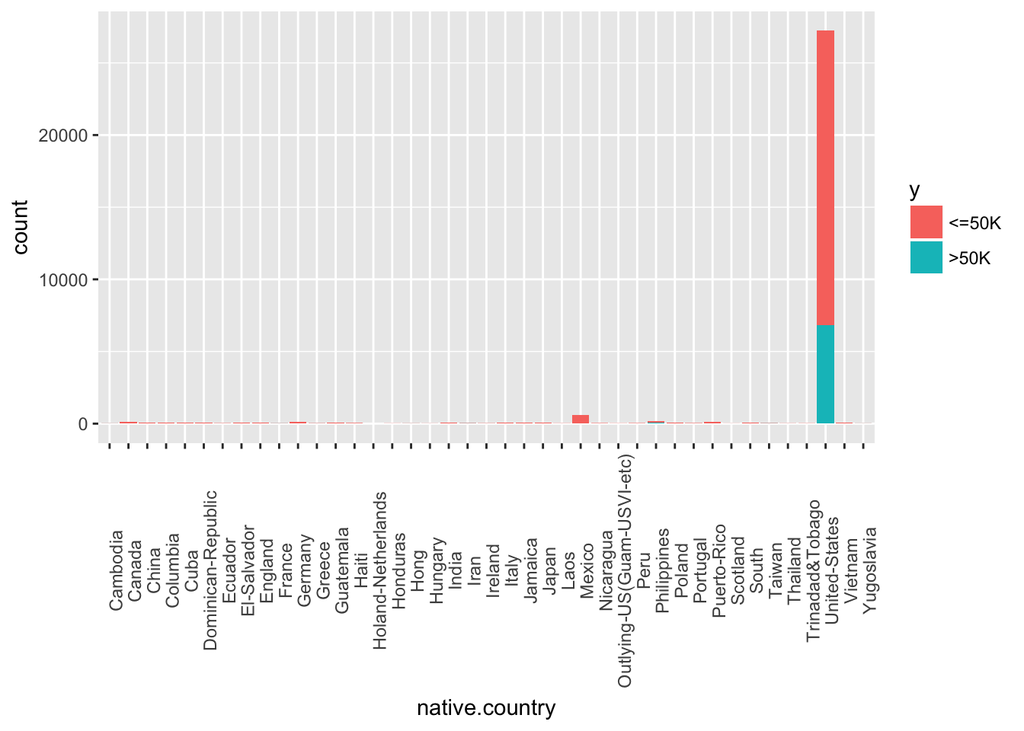

```r
# native.country variable
ggplot(train)+geom_bar(aes(x=native.country,fill=y))+theme(axis.text.x=element_text(angle=90))
```

14. For the **native.country**, 91% of people are `United-States`. There are several levels that just have a very small amount of people. But here we retain them to train our models, we can consider classifying them as one level if needed. However, there is just one person who comes from `Holand-Netherlands`, we must transform it into its most similiar level–`England`

```r
# change the native.country variable
train$native.country = as.character(train$native.country)
train$native.country[train$native.country=='Holand-Netherlands'] = 'England'
train$native.country = as.factor(train$native.country)
```

15. For **y** variable, this is our lable (usually, we can encode it as 0 and 1, but I prefer the original characters for its intuition ). About 76% people are `<=50K` and 24% people are `>50K`. Therefore, this is a unbalanced two-classification problem. So when we evaluate our models, in addition to accuracy, we should also consider their precision, recall, F1-score, auc, etc.

##### (4) Standardize data

```r
# before we standarized the numerical variables, we keep a copy of un-standarized data, for the use of validation
unstandarized_train = train

# the columns of numerical data
numeri_col = c(1,3,5,11,12,13)
temp = train[,numeri_col]
maxdata = apply(temp,2,max)
mindata = apply(temp,2,min)
#train[,numeri_col] = (train[,numeri_col]-mindata)/(maxdata-mindata)
max_train = rep(maxdata,each=dim(train)[1])
min_train = rep(mindata,each=dim(train)[1])
# standarize the data set
train[,numeri_col] = (train[,numeri_col]-min_train)/(max_train-min_train)
```

### clean the test data

For the test data, with the same method, we make the summary for the test data, and see that there are some observations that have unknown value in **workclass** or **native.country**. But instead of deleting these observations, here we replace these unknown values with the mode in their corresponding variables, because here we can consider the test data as the real data, and we want to use them to test the authentic performance of our models (for the test data, we can not ignore them just because they have unknown values. Actually, in real life, we sometimes will also come across such data but we still have to make predictions for our customers).

The following codes are to clean the test data, with the same procedure of cleaning train data.

```r
# deleting the duplicated data
test = unique(test)

# change the unknown workclass
test$workclass = as.character(test$workclass)
test$workclass[test$workclass=='?'] = 'Private'

# Because in the train data, there is no 'Never-worked' level in the workclass variables, so here in the test data, we can transform the 'Never-worked' into the 'Without-pay' level because there are just very small amount of people who are 'Never-worked', and also becasue 'Without-pay' level is very similar to 'Never-worked' level, the transformation won't have great impact on the prediction
test$workclass[test$workclass=='Never-worked'] = 'Without-pay'
test$workclass = as.factor(test$workclass)

# change the unknown native.country
test$native.country = as.character(test$native.country)
test$native.country[test$native.country=='?'] = 'United-States'
test$native.country = as.factor(test$native.country)

# The same as the transformation of train data, change the ' Amer-Indian-Eskimo' into ' Other'
test$race = as.character(test$race)
test$race[test$race=='Amer-Indian-Eskimo']='Other'
test$race = as.factor(test$race)



# The same as the transformation of train data, change the ' Married-AF-spouse' into ' Married-spouse-absent'
test$marital.status = as.character(test$marital.status)
test$marital.status[test$marital.status =='Married-AF-spouse'] = 'Married-spouse-absent'
test$marital.status = as.factor(test$marital.status)


# The same as the transformation of train data, change the ' Armed-Forces' into ' Other-service' and change the '?' into 'Prof-specialty'
test$occupation = as.character(test$occupation)
test$occupation[test$occupation == '?'] = 'Prof-specialty'
test$occupation[test$occupation=='Armed-Forces'] = 'Other-service'
test$occupation = as.factor(test$occupation)

# make a log transformation
test$capital.gain = log(test$capital.gain+1)
test$capital.loss = log(test$capital.loss+1)

# change the y variable, since there is period in every value of test$y, so let's change it.
test$y = as.character(test$y)
test$y[test$y == '>50K.'] = '>50K'
test$y[test$y == '<=50K.'] = '<=50K'
test$y = as.factor(test$y)


# before we standarized the numerical variables, we keep a copy of un-standarized data, for the use of validation
unstandarized_test = test

# apply the same transformation to the numerical variables in the test data, but use the maximum and minimum value of train data
min_test = rep(mindata,each=dim(test)[1])
max_test = rep(maxdata,each=dim(test)[1])
test[,numeri_col] = (test[,numeri_col]-min_test)/(max_test-min_test)
```

## Validation

```r
# summary for the cleaned train data
summary(train)
```

```
##       age                    workclass         fnlwgt
##  Min.   :0.0000   Federal-gov     :  939   Min.   :0.0000
##  1st Qu.:0.1507   Local-gov       : 2055   1st Qu.:0.1787
##  Median :0.2740   Private         :22067   Median :0.2829
##  Mean   :0.2934   Self-emp-inc    : 1038   Mean   :0.2988
##  3rd Qu.:0.4110   Self-emp-not-inc: 2465   3rd Qu.:0.3836
##  Max.   :1.0000   State-gov       : 1272   Max.   :1.0000
##                   Without-pay     :   14
##         education    education.num                  marital.status
##  HS-grad     :9769   Min.   :0.0000   Divorced             : 4183
##  Some-college:6630   1st Qu.:0.5333   Married-civ-spouse   :13885
##  Bachelors   :4976   Median :0.6000   Married-spouse-absent:  387
##  Masters     :1601   Mean   :0.6073   Never-married        : 9645
##  Assoc-voc   :1303   3rd Qu.:0.7333   Separated            :  929
##  11th        :1044   Max.   :1.0000   Widowed              :  821
##  (Other)     :4527
##            occupation           relationship                   race
##  Craft-repair   :3997   Husband       :12298   Asian-Pac-Islander:  887
##  Prof-specialty :3956   Not-in-family : 7656   Black             : 2764
##  Exec-managerial:3938   Other-relative:  887   Other             :  515
##  Adm-clerical   :3698   Own-child     : 4434   White             :25684
##  Sales          :3543   Unmarried     : 3183
##  Other-service  :3201   Wife          : 1392
##  (Other)        :7517
##      sex         capital.gain      capital.loss     hours.per.week
##  Female: 9704   Min.   :0.00000   Min.   :0.00000   Min.   :0.000
##  Male  :20146   1st Qu.:0.00000   1st Qu.:0.00000   1st Qu.:0.398
##                 Median :0.00000   Median :0.00000   Median :0.398
##                 Mean   :0.06505   Mean   :0.04325   Mean   :0.407
##                 3rd Qu.:0.00000   3rd Qu.:0.00000   3rd Qu.:0.449
##                 Max.   :1.00000   Max.   :1.00000   Max.   :1.000
##
##        native.country      y
##  United-States:27226   <=50K:22523
##  Mexico       :  597   >50K : 7327
##  Philippines  :  187
##  Germany      :  127
##  Puerto-Rico  :  109
##  Canada       :  106
##  (Other)      : 1498
```

```r
# summary for the cleaned test data
summary(test)
```

```
##       age                    workclass         fnlwgt
##  Min.   :0.0000   Federal-gov     :  472   Min.   :-0.0004772
##  1st Qu.:0.1507   Local-gov       : 1043   1st Qu.: 0.1774144
##  Median :0.2740   Private         :12169   Median : 0.2826592
##  Mean   :0.2982   Self-emp-inc    :  578   Mean   : 0.3026666
##  3rd Qu.:0.4247   Self-emp-not-inc: 1321   3rd Qu.: 0.3869883
##  Max.   :1.0000   State-gov       :  683   Max.   : 2.5440820
##                   Without-pay     :   10
##         education    education.num                  marital.status
##  HS-grad     :5283   Min.   :0.0000   Divorced             :2189
##  Some-college:3587   1st Qu.:0.5333   Married-civ-spouse   :7402
##  Bachelors   :2667   Median :0.6000   Married-spouse-absent: 224
##  Masters     : 934   Mean   :0.6048   Never-married        :5431
##  Assoc-voc   : 678   3rd Qu.:0.7333   Separated            : 505
##  11th        : 637   Max.   :1.0000   Widowed              : 525
##  (Other)     :2490
##            occupation           relationship                  race
##  Prof-specialty :2997   Husband       :6522   Asian-Pac-Islander:  480
##  Exec-managerial:2019   Not-in-family :4275   Black             : 1561
##  Craft-repair   :2013   Other-relative: 525   Other             :  294
##  Sales          :1854   Own-child     :2512   White             :13941
##  Adm-clerical   :1840   Unmarried     :1679
##  Other-service  :1634   Wife          : 763
##  (Other)        :3919
##      sex         capital.gain      capital.loss     hours.per.week
##  Female: 5420   Min.   :0.00000   Min.   :0.00000   Min.   :0.000
##  Male  :10856   1st Qu.:0.00000   1st Qu.:0.00000   1st Qu.:0.398
##                 Median :0.00000   Median :0.00000   Median :0.398
##                 Mean   :0.06742   Mean   :0.04262   Mean   :0.402
##                 3rd Qu.:0.00000   3rd Qu.:0.00000   3rd Qu.:0.449
##                 Max.   :1.08317   Max.   :0.99590   Max.   :1.000
##
##        native.country      y
##  United-States:14931   <=50K:12430
##  Mexico       :  308   >50K : 3846
##  Philippines  :   97
##  Puerto-Rico  :   70
##  Germany      :   69
##  Canada       :   61
##  (Other)      :  740
```

```r
# apply the validation function (source and instruction can be seen in the Validation.R)
validation(unstandarized_train)
```

```
## [1] "The data set is valid !"
```

```r
validation(unstandarized_test)
```

```
## [1] "The data set is valid !"
```

## Models

```r
# Model 1
set.seed(1234)
time = proc.time()
rt = rpart(train$y~.,data=train)
pred1 = predict(rt, test, type = "class")
# the time used for runing this model
rt_runtime = (proc.time()-time)[3]

# the performan on the test data (evaluation can be checked in evaluation.R)
rt_performance = evaluation(pred1,test$y)
# see the accuracy,precision,recall and F1-score
rt_performance
```

```
## [1] 0.8445564 0.7556333 0.5057202 0.6059190
```

##### Evaluation

```r
# let's see this model's performance for the train data
pred1_train = predict(rt, train, type = "class")
# the performan on the train data
rt_performance_train = evaluation(pred1_train,train$y)
# see the accuracy,precision,recall and F1-score
rt_performance_train
```

```
## [1] 0.8400000 0.7668968 0.5002047 0.6054849
```

Comparing the model’s performance on train data and test data, they are very similar. So we can think that this model is not overfitting and we don’t need pruning. So this model has been performing almostly its best for us.

### Model2: Random Forest

```r
# Model2
set.seed(1234)
time = proc.time()
rf = randomForest(y ~ ., data=train,importance = TRUE, proximity = FALSE, ntree = 100)
pred2 = predict(rf,test,type='class')
# the time used for running this model
rf_runtime = (proc.time()-time)[3]

# the performan on the test data
rf_performance = evaluation(pred2,test$y)
# see the accuracy,precision,recall and F1-score
rf_performance
```

```
## [1] 0.8247727 0.9610390 0.2693708 0.4207961
```

##### Evaluation

```r
# Actually we found that using AUC to get a better threshold, can help up make an improvement for this model

# predict the probability instead of class
p_train = predict(rf,train,type='prob')[,2]
# apply my find_best_p function to determine the threshold (can be checked in find_best_p.R)
threshold = find_best_p(p_train,train$y)
```

[figure not shown]

```r
# make a prediction for test data
p_test = predict(rf,test,type='prob')[,2]

pred2=test$y
pred2[p_test>threshold] = '>50K'
pred2[p_test<=threshold] = '<=50K'

rf_performance = evaluation(pred2,test$y)
# see the accuracy,precision,recall and F1-score
rf_performance
```

```
## [1] 0.8277832 0.6313933 0.6515861 0.6413308
```

We can see that this model has been improved a lot on the F1-score. Because it has improved a lot for its recall, meaning the stronger ability of finding those who are `>50K`. It makes sense, because this is exactly our goal,finding those who are `>50K`. And also, the accuracy improve slightly, though it’s just a litte bit of improvement.

### Model3: Support Vector Machine

```r
set.seed(1234)
time = proc.time()

svm = ksvm(y ~ ., data = train, C=1)
pred3 = predict(svm,test)
# the time used for running this model
svm_runtime = (proc.time()-time)[3]

# the performan on the test data
svm_performance = evaluation(pred3,test$y)
# see the accuracy,precision,recall and F1-score
svm_performance
```

```
## [1] 0.8552470 0.7475083 0.5850234 0.6563594
```

##### Evaluation

```r
# let's see this model's performance for the train data
pred3_train = predict(svm, train)
# the performan on the train data
svm_performance_train = evaluation(pred3_train,train$y)
# see the accuracy,precision,recall and F1-score
svm_performance_train
```

```
## [1] 0.8608710 0.7807856 0.6022929 0.6800216
```

```r
# we can see that there is a gap between the performance on train data and test data,
# So, to some extend, the original model is a little bit overfitting. So we can increase the penalty to make a better model


#penalty_list = c(1.2, 1.4, 1.6, 2, 5)
#for( penalty in penalty_list){
#  svm = ksvm(y ~ ., data = train, C = penalty)
#  pred = predict(svm, test)
#  print(penalty)
#  print(evaluation(pred,test$y))
#}

set.seed(1234)
svm = ksvm(y ~ ., data = train, C = 1.6)
pred3 = predict(svm, test)
# the performan on the test data
svm_performance = evaluation(pred3,test$y)
# see the accuracy,precision,recall and F1-score
svm_performance
```

```
## [1] 0.8572745 0.7491004 0.5954238 0.6634796
```

## Comparison

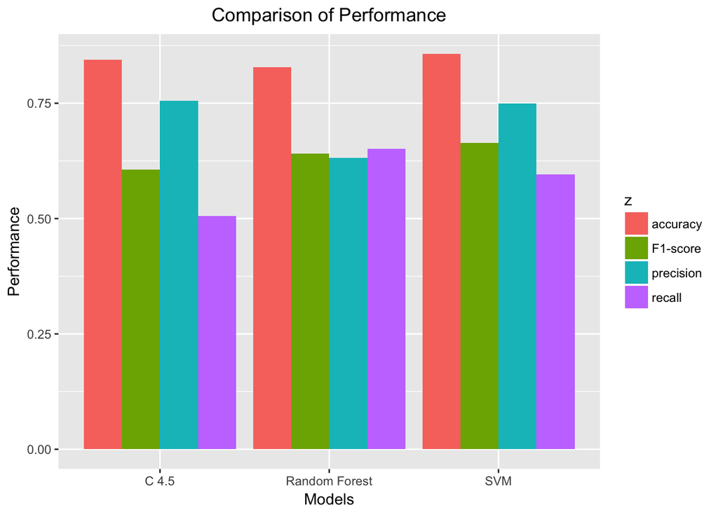

| Models | Accuracy | F1-score | Precision | Recall | Running Time |
| --- | --- | --- | --- | --- | --- |
| C 4.5 | 0.845 | 0.606 | 0.756 | 0.506 | 1.188 |
| Random Forest | 0.828 | 0.641 | 0.631 | 0.652 | 15.128 |
| SVM | 0.857 | 0.663 | 0.749 | 0.595 | 95.508 |

```r
# Compare the accuracy, precision, recall, F1-score and running-time
model_names=c('C 4.5','Random Forest','SVM')
x=rep(model_names,each = 4)
y=c(rt_performance,rf_performance,svm_performance)
z=rep(c('accuracy','precision','recall','F1-score'),3)
df=data.frame(x=x,y=y,z=z)
ggplot(data = df, mapping = aes(x = x, y = y,fill = z)) + geom_bar(stat = 'identity', position = 'dodge') + labs(x='Models',y='Performance',title='Comparison of Performance') + theme(plot.title=element_text(hjust=0.5))
```

**From the table and picture, we can see that, SVM has the highest accuracy and F1-score. C4.5 has the second highest accuracy and highest precision. But it’s recall is lowest, leading to its low F1-score. Random Forest is just slightly worse than SVM both in accuracy and F1-score, but has the highest recall. With the Consideration of the running time, I prefer to Random Forset in this case.**

## Reference:

1. http://www.cnblogs.com/liuyangnuts/archive/2013/04/10/3013001.html
2. http://www.cellyse.com/how_to_use_gggplot2_part1/
3. http://zh.wikihow.com/%E8%AE%A1%E7%AE%97%E5%BC%82%E5%B8%B8%E5%80%BC
4. https://mran.microsoft.com/web/packages/pROC/pROC.pdf
5. http://www.voidcn.com/blog/a358463121/article/p-6005933.html
6. https://www.ibm.com/developerworks/cn/analytics/library/ba-1507-decisiontree-algorithm/
7. https://en.wikipedia.org/wiki/C4.5_algorithm